# A Dynamic Analysis of the Market for Wide-Bodied Commercial Aircraft

March 3, 2019

## Motivation

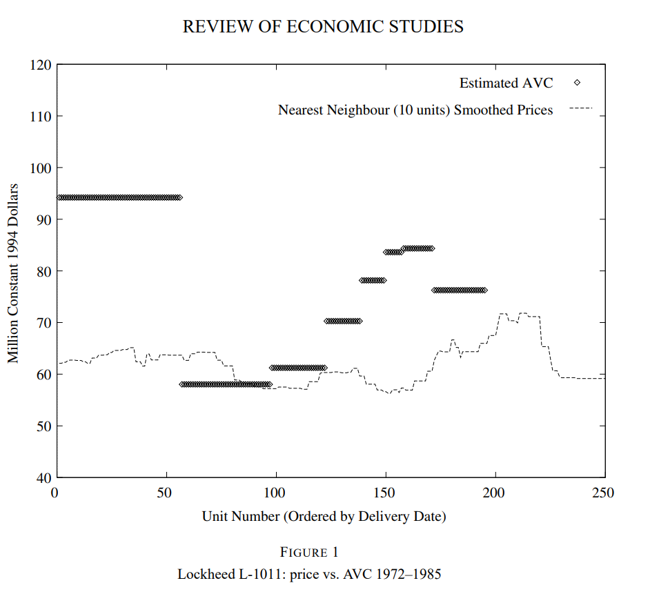

## Motivation cont.

- Policy: airlines are the target of industrials policy
- Past theoretical literature finds that under certain conditions an unrestrained monopoly may pareto-dominate an oligopoly

## Empirical Strategy

- Develop dynamic model with learning curves, differentiated products, entry costs, and closed loop strategic interaction
- Estimate the primitives of the model
- Find equilibrium

## Theoretical Model

- Dynamic programming problem
- Products indexed by \(j \in \mathbb{N}\), time periods indexed by \(t \in \mathbb{N}\)
- Three state variables per product, experience with product-j
- \(E_{jt} \in \mathcal{E}\),- the product's "type" \(\mu_j \in \mathcal{A}\) and
- the product's quality \(\xi_{jt} \in \mathcal{X}\)
- Sets \(\mathcal{E}, \mathcal{A}, \mathcal{X}\) are sets of possible experience levels, product types and product quality levels.

## Incumbent's Bellman system

\[V(i,s,M)=max_{\chi_i^e,\chi_j,q_j\forall j\in \mathcal{J}_i}\{-\sum_{k=1}^31\{\chi^3_i=k\}x_k^e\] \[ + \sum_{j\in\mathcal{J}_i}[\chi_j\Phi_{jt}+(1-\chi_j)\pi_j(i,s,q,M)]\] \[+ \beta \sum_{i',s',M'}V(i',s',M')\mathcal{P}(i',s',M'\vert i,s,q,M,\chi,chi^e)\}\] - Note that the strategy space for the firm includes quantity and not price as control variables.

## Potential Entrant's Bellman system

-\[V^e(s,M)=max_{\chi_i^e\in\{0,1,2,3\}}-\sum_{k=1}^31\{\chi_i^e=k\}x_k^e\] \[+\beta\sum_{i',s',M'}V(i^e,s',M')\mathcal{P}(i^e,s',M'|s,q,M,\chi,\chi^e)\]

## Profit function

\[\pi_j(i,s,q,M)=p_j(i,s,q,M)q_j-c_j(i,q_j)\]

## Equilibrium

- Equilibrium in this model is "Markov perfect Nash Equilibrium(MPE)"
- MPEs are a subset of subgame-perfect nash equilibria wherein best-response functions are functions only of payoff relevant state variables.
- Restrict equilibria further to symmetric equilibria
- Symmetry means that two firms, if facing identical states and identical competitors must follow the same strategy.

## Estimating the model

-labor demand is: \[lnL_{lt}=lnA+\theta lnE_t+\gamma lnS_t+\varepsilon_{lt}\] - \(L_{lt}\) is labor input for good \(l\) at time \(t\), \(A\) is a constant, \(E_t\) is experience, \(\varepsilon_{lt}\) is a plane-specific productivity shock, \(S_t\) is line-speed or the production rate.